# IDS investigation worksheet

by Team-Name: Hannah, Hannah, Rianna

2026-11-27

- road and alley access - filter to check if both needed - remove alley if not needed
- basement columns probably remove
- most important columns to focus on: years built and remodelled
- potential question: what is the most influential variable that influences finished house prices in central Amestown (Iowa): - can change to sepcific relationships –> possible variables that this could consider: period of remodelling, condition of various features of the house - quality ratings overall quality overall condition etc., size of house - unfinished/ outliers, when originally built
- original data set size: 82 variables, 2930 observations
- central area = SWISSU, College Creek, Edwards, Old Town, IDOTRR, Brookside, Crawford
- count SWISSU = 48, count College Creek = 267, count Edwards = 194, count Old Town = 239, count IDOTRR = 93, count Brookside = 108, count Crawford = 103 code: House_data_iowa %>% count(Neighborhood) %>%

- ```
      print(n=28)
  ```

IMPORTANT NOTE FROM DATASET PUBLISHER : SPECIAL NOTES: “There are 5 observations that an instructor may wish to remove from the data set before giving it to students (a plot of SALE PRICE versus GR LIV AREA will indicate them quickly). Three of them are true outliers (Partial Sales that likely don’t represent actual market values) and two of them are simply unusual sales (very large houses priced relatively appropriately). I would recommend removing any houses with more than 4000 square feet from the data set (which eliminates these 5 unusual observations) before assigning it to students.” - potentially could remove/ acknowlegde outliers = 3 got low price despite larger square feet due to being partial sale (lower price than others)

Year built = Victorian and gilded age (1830s - 1910s), Interwar (1920s-1945), Post-War (1945 - 1970s), 20th century (1980s-present) Remodel = 50s, 60s&70s, 80s&90s, 2000s

Overall quality is how well a house is built and condition is how well a house was maintained.

Add a grpah for the prices of housing sold before and after 2008.

```r
library(tidyverse)
library(tidymodels)
# Add any other libraries here
```

```r
# load your data
library(readr)
House_data_iowa <-read_csv("House data iowa.csv")
central_area_data <- House_data_iowa %>%
  filter(Neighborhood == c("SWISU", "BrkSide", "CollgCr", "Crawfor", "Edwards", "IDOTRR", "OldTown"))
view(central_area_data)
which(is.na(central_area_data), arr.ind = T)
```

```
##        row col
##   [1,]   7   7
##   [2,]   9   7
##   [3,]  21   7
##   [4,]  23   7
##   [5,]  35   7
##   [6,]  36   7
##   [7,]  38   7
##   [8,]  43   7
##   [9,]  46   7
##  [10,]  58   7
##  [11,]  65   7
##  [12,]  93   7
##  [13,] 107   7
##  [14,] 108   7
```

[output cut: 659 more lines]

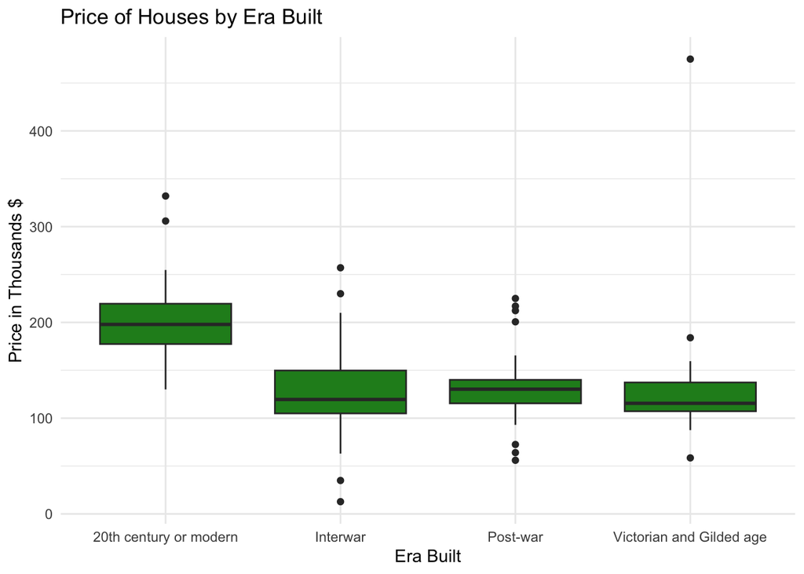

```r
central_area_data <- central_area_data %>% filter(area < 4000)

central_data_with_eras <- central_area_data %>%
  mutate(
    era_built = case_when(
      Year.Built < 1913 ~ "Victorian and Gilded age",
      Year.Built > 1913 & Year.Built <= 1945 ~ "Interwar",
      Year.Built > 1945 & Year.Built < 1980 ~ "Post-war",
      Year.Built >= 1980 ~ "20th century or modern"
    ),
    era_remodelled = case_when(
      Year.Remod.Add < 1960 ~ "1950s",
      Year.Remod.Add >= 1960 & Year.Remod.Add < 1980 ~ "1960s and 1970s",
      Year.Remod.Add >= 1980 & Year.Remod.Add < 2000 ~ "1980s and 1990s",
      Year.Remod.Add >= 2000 ~ "2000s"
    )
  )

view(central_data_with_eras)

central_data_with_eras <- central_data_with_eras %>%
  mutate(price_k = price/1000)

central_data_with_eras %>%
  ggplot(aes(x = era_built, y = price_k)) +
  geom_boxplot(fill = "forestgreen") +
  labs(title = "Price of Houses by Era Built",
       x = "Era Built",
       y = "Price in Thousands $") +
  theme_minimal() +
  theme(legend.position = "none")
```

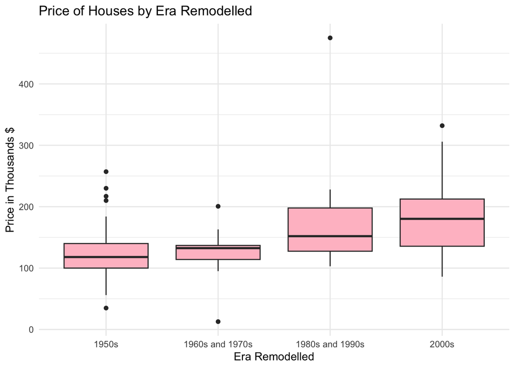

```r
central_data_with_eras %>%
  ggplot(aes(x = era_remodelled, y = price_k)) +
  geom_boxplot(fill = "pink") +
  labs(title = "Price of Houses by Era Remodelled",
       x = "Era Remodelled",
       y = "Price in Thousands $") +
  theme_minimal() +
  theme(legend.position = "none")
```

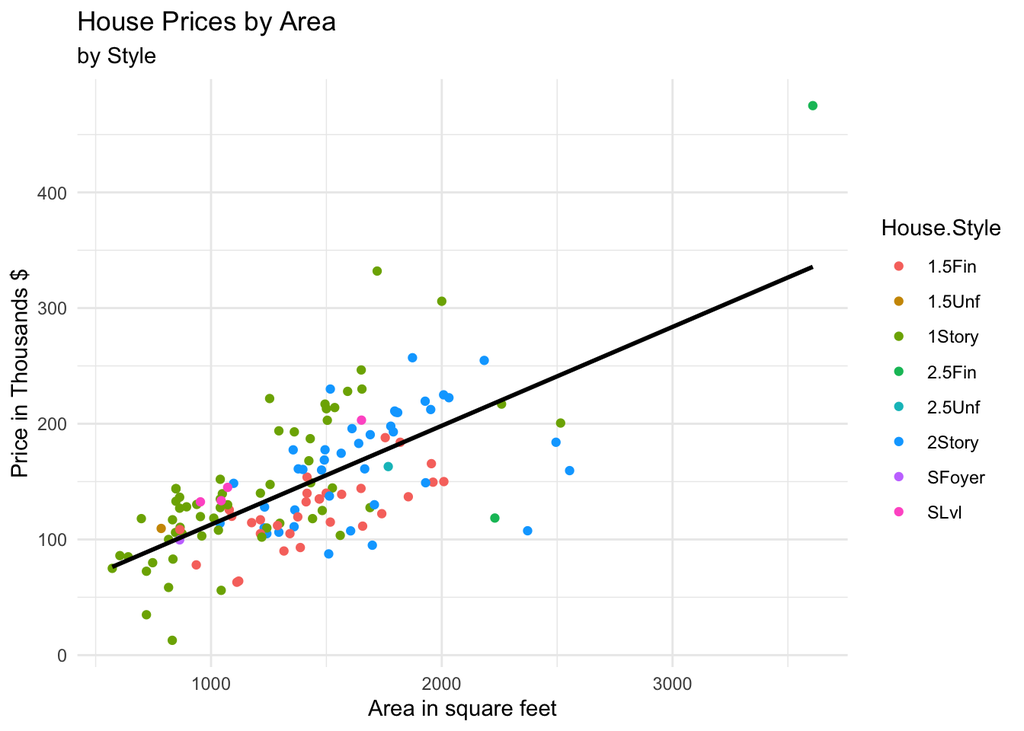

```r
central_data_with_eras %>%
  ggplot(aes(x = area, y = price_k)) +
  geom_point(aes(colour = House.Style)) +
  geom_smooth(method = "lm", se = FALSE, colour = "black") +
  labs(title = "House Prices by Area",
       subtitle = "by Style",
       x = "Area in square feet",
       y = "Price in Thousands $") +
  theme_minimal()
```

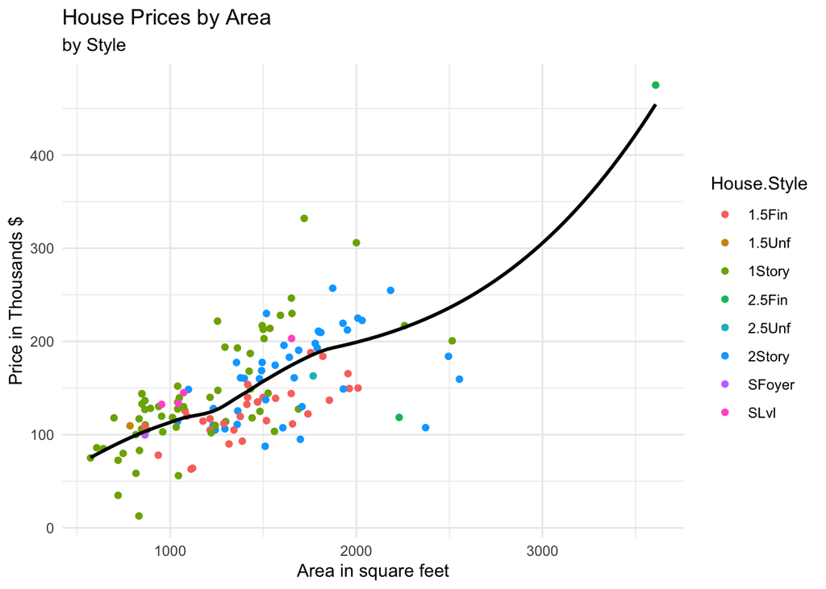

```r
central_data_with_eras %>%
  ggplot(aes(x = area, y = price_k)) +
  geom_point(aes(colour = House.Style)) +
  geom_smooth(method = "loess", se = FALSE, colour = "black") +
  labs(title = "House Prices by Area",
       subtitle = "by Style",
       x = "Area in square feet",
       y = "Price in Thousands $") +
  theme_minimal()
```

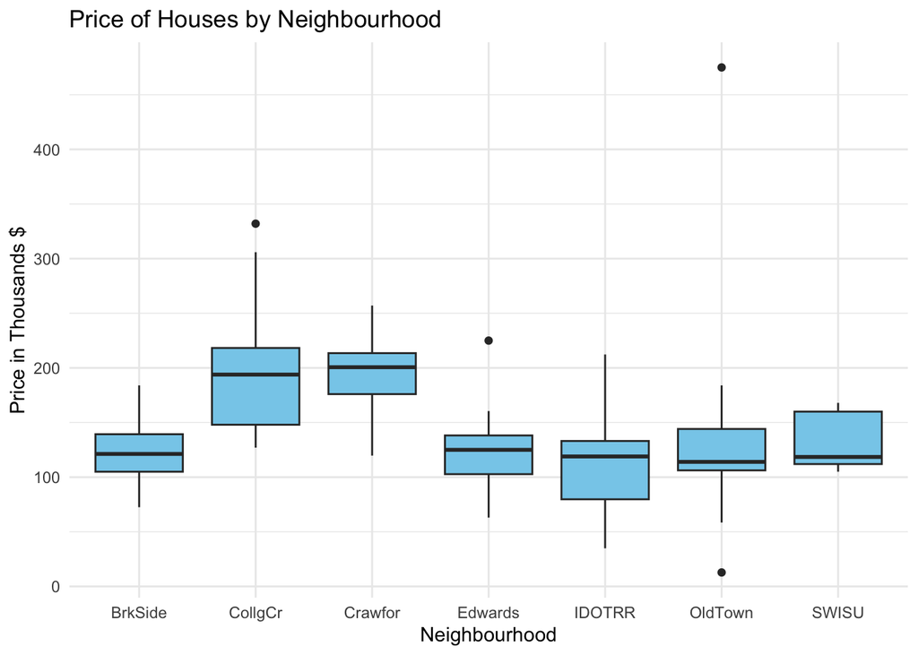

```r
central_data_with_eras %>%
     ggplot(aes(x = Neighborhood, y = price_k)) +
     geom_boxplot(fill = "skyblue") +
 labs(title = "Price of Houses by Neighbourhood",
        x = "Neighbourhood",
        y = "Price in Thousands $") +
   theme_minimal()
```

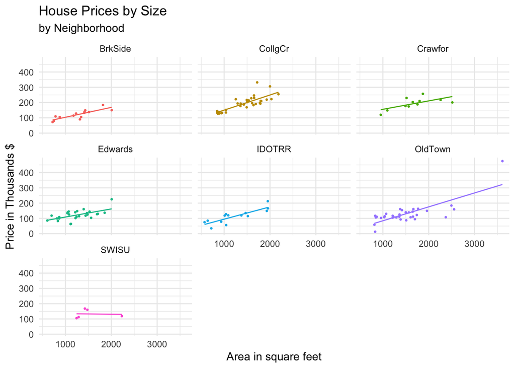

```r
central_data_with_eras %>%
    ggplot(aes(x = area, y = price_k, colour = Neighborhood)) +
    geom_point(size = 0.5) +
    geom_smooth(method = "lm", se = FALSE, linewidth = 0.5) +
    labs(title = "House Prices by Size",
         subtitle = "by Neighborhood",
         x = "Area in square feet",
         y = "Price in Thousands $") +
    facet_wrap(~Neighborhood) +
    theme_minimal() +
    theme(legend.position = "none")
```

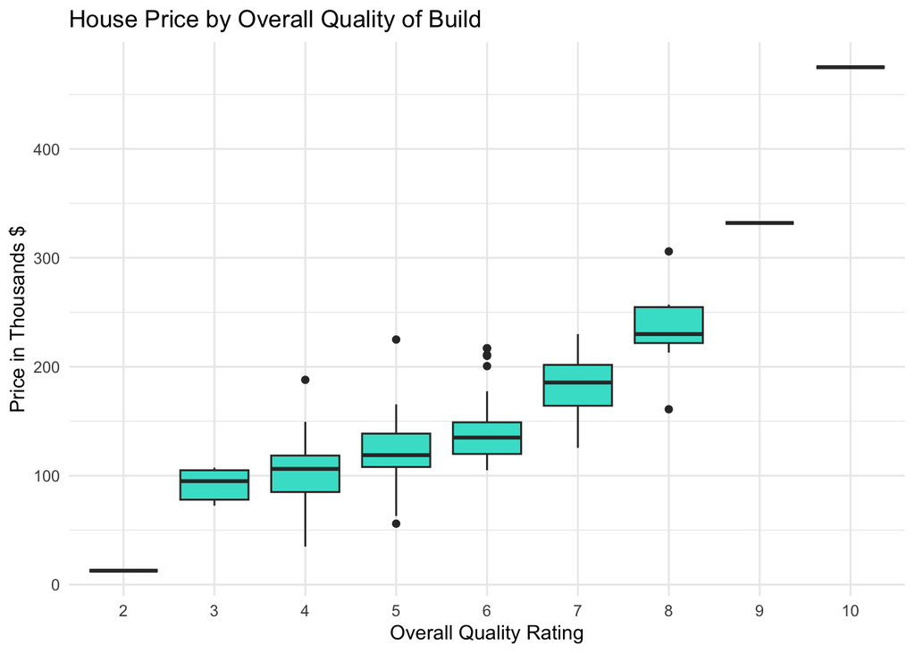

```r
central_data_with_eras$Overall.Qual <- as.character(central_data_with_eras$Overall.Qual)
central_data_with_eras$Overall.Qual <- factor(central_data_with_eras$Overall.Qual, levels = c("2", "3", "4", "5", "6", "7", "8", "9", "10"))

central_data_with_eras %>%
  ggplot(aes(x = Overall.Qual, y = price_k)) +
  geom_boxplot(fill = "turquoise") +
  labs(
    title = "House Price by Overall Quality of Build",
    x = "Overall Quality Rating",
    y = "Price in Thousands $"
  ) +
  theme_minimal()
```

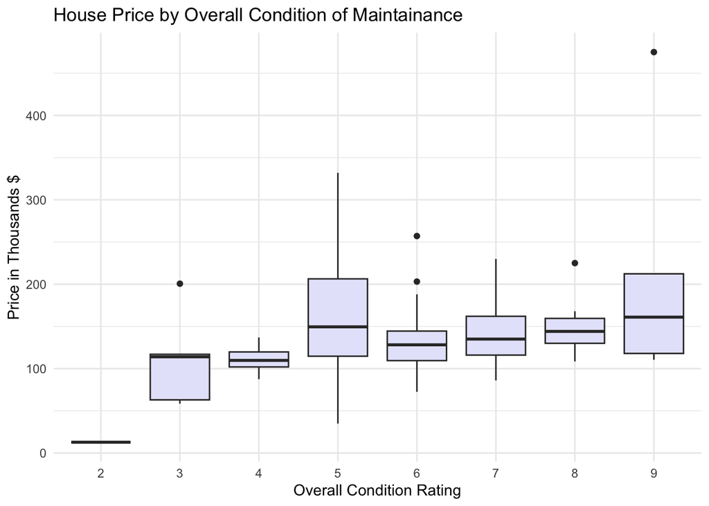

```r
central_data_with_eras$Overall.Cond <- as.character(central_data_with_eras$Overall.Cond)

central_data_with_eras %>%
  ggplot(aes(x = Overall.Cond, y = price_k)) +
  geom_boxplot(fill = "lavender") +
  labs(
    title = "House Price by Overall Condition of Maintainance",
    x = "Overall Condition Rating",
    y = "Price in Thousands $"
  ) +
  theme_minimal()
```

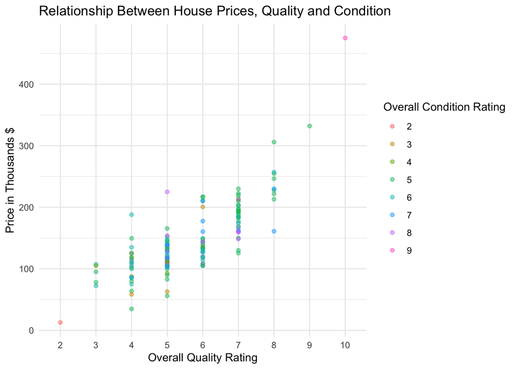

```r
central_data_with_eras %>%
  ggplot(aes(x = Overall.Qual, y = price_k, colour = Overall.Cond)) +
  geom_point(alpha = 0.5) +
  labs(
    title = "Relationship Between House Prices, Quality and Condition",
    x = "Overall Quality Rating",
    y = "Price in Thousands $",
    colour = "Overall Condition Rating"
  ) +
  theme_minimal()
```

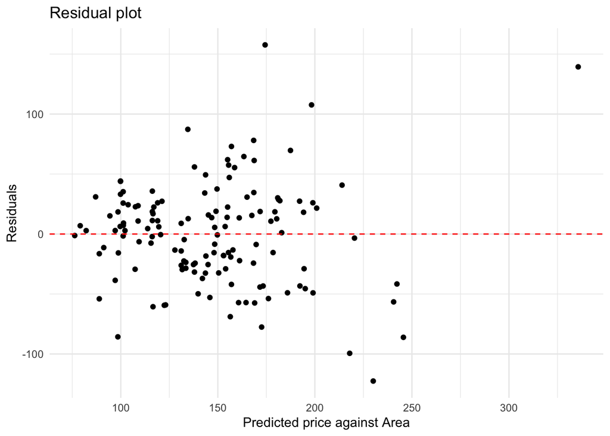

```r
price_fit <- lm(price_k ~ area, data = central_data_with_eras)

augmented_data <- augment(price_fit)
ggplot(augmented_data, aes(x = .fitted, y = .resid)) +
  geom_point() +
  geom_hline(yintercept = 0, linetype = "dashed", colour = "red") +
  labs(
    title = "Residual plot",
    x = "Predicted price against Area",
    y = "Residuals"
  ) +
  theme_minimal()
```

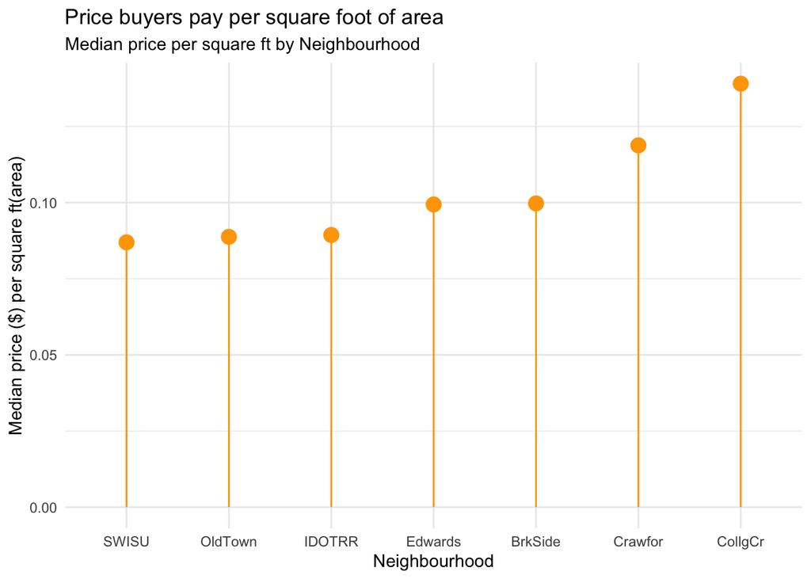

```r
central_data_with_eras <- central_data_with_eras %>%
  mutate(price_per_sq_ft = price_k / area)
neighbourhood_price_per_sq_ft <- central_data_with_eras %>%
  group_by(Neighborhood) %>%
  summarise(median_price_per_sq_ft = median(price_per_sq_ft, na.rm = TRUE))

ggplot(neighbourhood_price_per_sq_ft, aes(x = reorder(Neighborhood, median_price_per_sq_ft), y = median_price_per_sq_ft)) +
  geom_segment(aes(xend = Neighborhood, y = 0, yend = median_price_per_sq_ft), colour = "orange") +
  geom_point(size = 4, colour = "orange") +
  labs(
    title = "Price buyers pay per square foot of area",
    subtitle = "Median price per square ft by Neighbourhood",
    x = "Neighbourhood",
    y = "Median price ($) per square ft(area)"
  ) +
  theme_minimal()
```

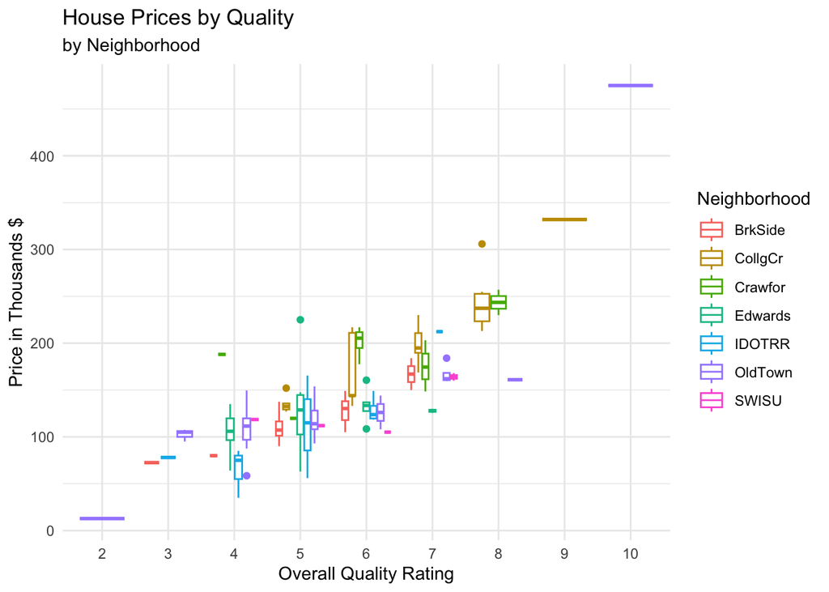

```r
central_data_with_eras %>%
    ggplot(aes(x = Overall.Qual, y = price_k, colour = Neighborhood)) +
    geom_boxplot() +
    labs(title = "House Prices by Quality",
         subtitle = "by Neighborhood",
         x = "Overall Quality Rating",
         y = "Price in Thousands $") +
    theme_minimal()
```

```r
central_data_with_eras %>%
  group_by(Neighborhood) %>%
  count(Overall.Qual)
```

```
## # A tibble: 36 × 3
## # Groups:   Neighborhood [7]
##    Neighborhood Overall.Qual     n
##    <chr>        <fct>        <int>
##  1 BrkSide      3                1
##  2 BrkSide      4                1
##  3 BrkSide      5                4
##  4 BrkSide      6                6
##  5 BrkSide      7                2
##  6 CollgCr      5                7
##  7 CollgCr      6                5
##  8 CollgCr      7               16
##  9 CollgCr      8                6
## 10 CollgCr      9                1
## # ℹ 26 more rows
```

```r
linear_reg() %>%
  set_engine("lm") %>%
  fit(price_k ~ area + Neighborhood + Overall.Qual, data = central_data_with_eras) %>%
  tidy()
```

```
## # A tibble: 16 × 5
##    term                estimate std.error statistic  p.value
##    <chr>                  <dbl>     <dbl>     <dbl>    <dbl>
##  1 (Intercept)         -22.2     22.3        -0.993 3.23e- 1
##  2 area                  0.0444   0.00503     8.82  9.16e-15
##  3 NeighborhoodCollgCr  42.7      7.14        5.97  2.31e- 8
##  4 NeighborhoodCrawfor  38.6      8.76        4.41  2.24e- 5
##  5 NeighborhoodEdwards   7.53     7.14        1.05  2.94e- 1
##  6 NeighborhoodIDOTRR   -2.22     7.97       -0.278 7.81e- 1
##  7 NeighborhoodOldTown  -1.95     7.12       -0.274 7.84e- 1
##  8 NeighborhoodSWISU    -3.54    11.1        -0.319 7.50e- 1
##  9 Overall.Qual3        60.6     23.2         2.61  1.03e- 2
## 10 Overall.Qual4        67.8     21.9         3.10  2.40e- 3
## 11 Overall.Qual5        81.6     21.6         3.77  2.49e- 4
## 12 Overall.Qual6        92.2     22.1         4.17  5.79e- 5
## 13 Overall.Qual7       105.      22.4         4.70  6.82e- 6
## 14 Overall.Qual8       146.      23.3         6.25  6.16e- 9
## 15 Overall.Qual9       235.      30.9         7.62  5.77e-12
## 16 Overall.Qual10      339.      32.8        10.3   2.09e-18
```

```r
linear_reg() %>%
  set_engine("lm") %>%
  fit(price_k ~ area, data = central_data_with_eras) %>%
  tidy()
```

```
## # A tibble: 2 × 5
##   term        estimate std.error statistic  p.value
##   <chr>          <dbl>     <dbl>     <dbl>    <dbl>
## 1 (Intercept)  27.4     11.6          2.36 1.97e- 2
## 2 area          0.0854   0.00788     10.8  3.76e-20
```

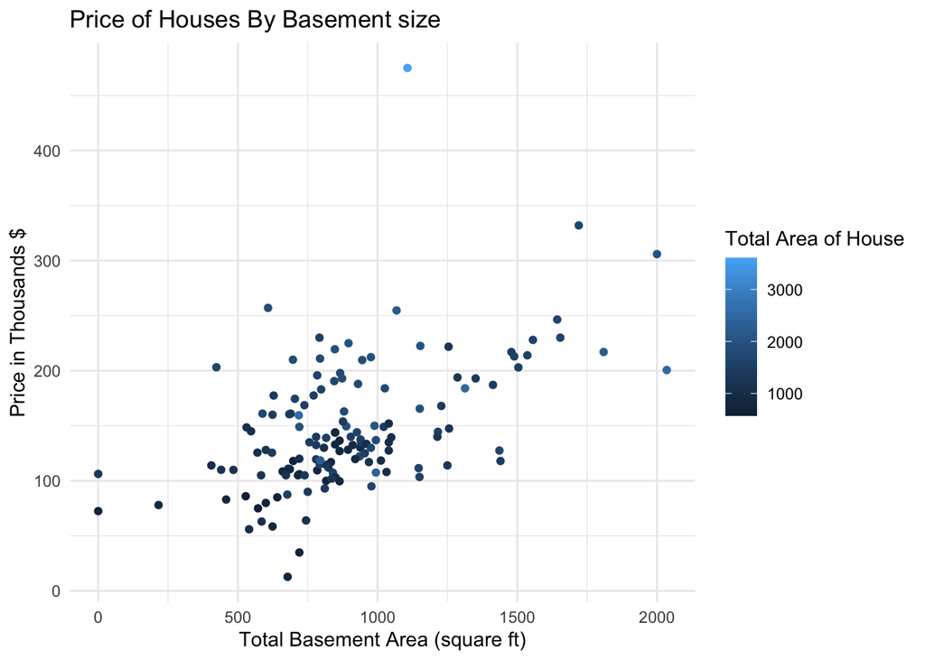

```r
central_data_with_eras %>%
  ggplot(aes(x = Total.Bsmt.SF, y = price_k, colour = area)) +
  geom_point() +
  labs(
    title = "Price of Houses By Basement size",
    x = "Total Basement Area (square ft)",
    y = "Price in Thousands $",
    colour = "Total Area of House") +
  theme_minimal()
```